# Class8:

Robertha Amezola

April 25, 2019

## K-means clustering

Example of running the **kmeans()** function

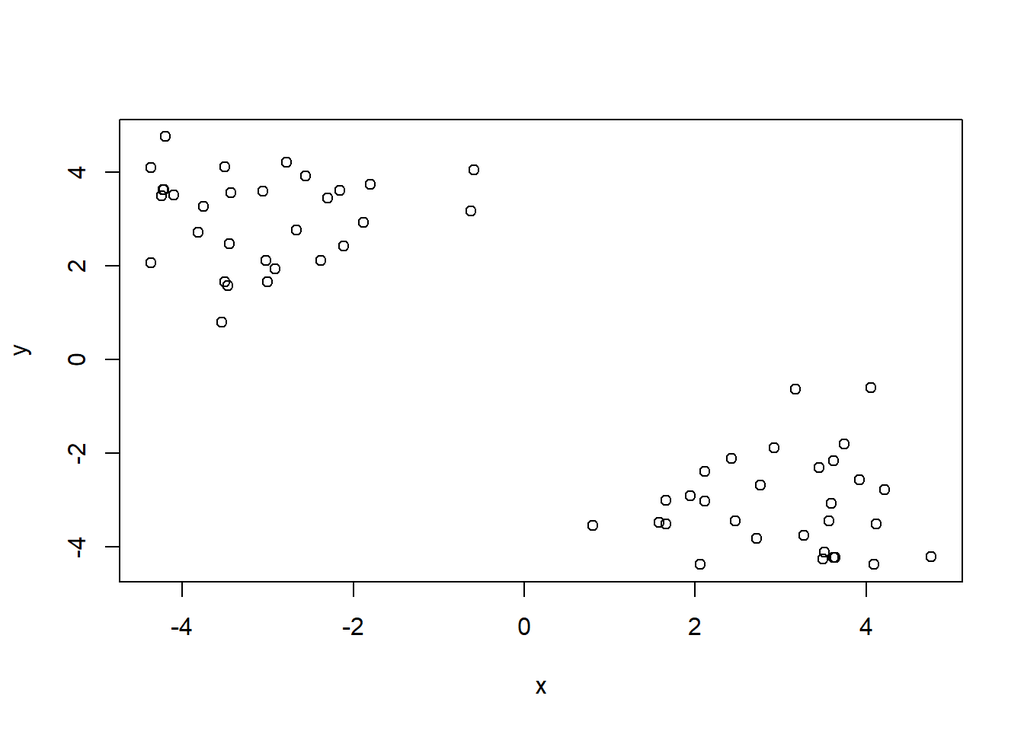

```r
tmp <- c(rnorm(30,-3), rnorm(30,3))
x <- cbind(x=tmp, y=rev(tmp))
plot(x)
```

To Do

```r
km=kmeans(x, centers=2, nstart=20)
```

```r
km$cluster
```

```
##  [1] 2 2 2 2 2 2 2 2 2 2 2 2 2 2 2 2 2 2 2 2 2 2 2 2 2 2 2 2 2 2 1 1 1 1 1
## [36] 1 1 1 1 1 1 1 1 1 1 1 1 1 1 1 1 1 1 1 1 1 1 1 1 1
```

```r
km$size
```

```
## [1] 30 30
```

```r
km$centers
```

```
##           x         y
## 1  3.036893 -3.068862
## 2 -3.068862  3.036893
```

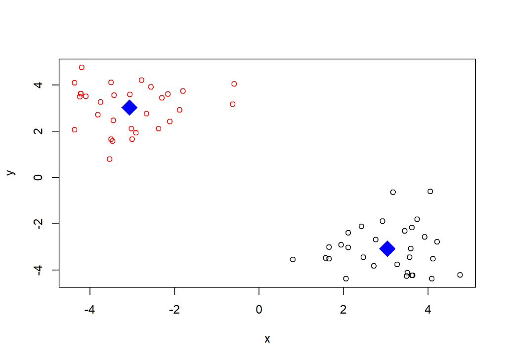

```r
plot(x, col=km$cluster)
points(km$centers, pch=18, col="blue", cex=3)
```

> Q. What ‘component’ of your result object details - cluster size? - cluster assignment/membership? - cluster center?

> Plot x colored by the kmeans cluster assignment and add cluster centers as blue points

```r
km <- kmeans(x, centers=2, nstart=20)
```

##Hierarchical Clustering example

**hclust** function a distance matrix not the raw data as an input

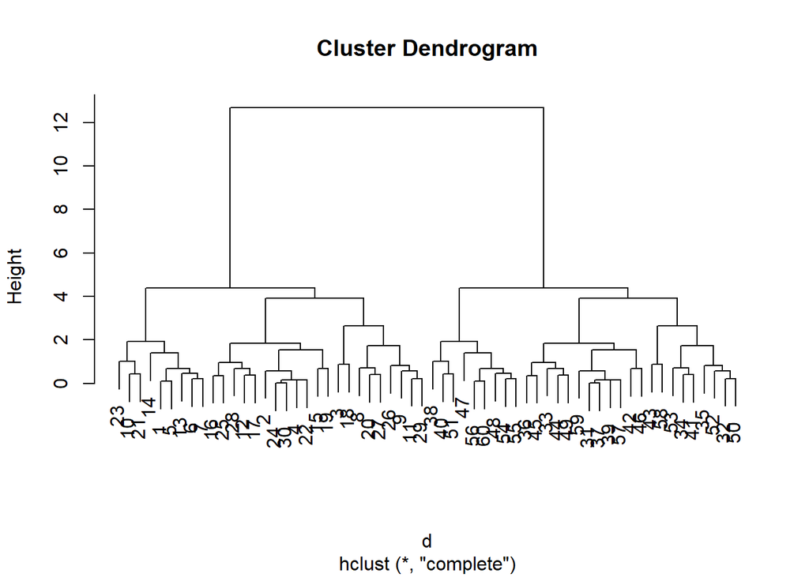

```r
##distanc ematrix calculation
d <- dist(x)

##clustering
hc<-hclust(d)
plot(hc)
```

# Create hierarchical cluster model: hc hc <- hclust(dist(x)) # We can plot the results as a dendrogram plot(hc) >What do you notice? the grah is hard to read >Does the dendrogram? every cluster (point) is then group into similar groupds >make sense based on? yes but you have to understand that is backgrads >your knowledge of x

##drwas dendrogram

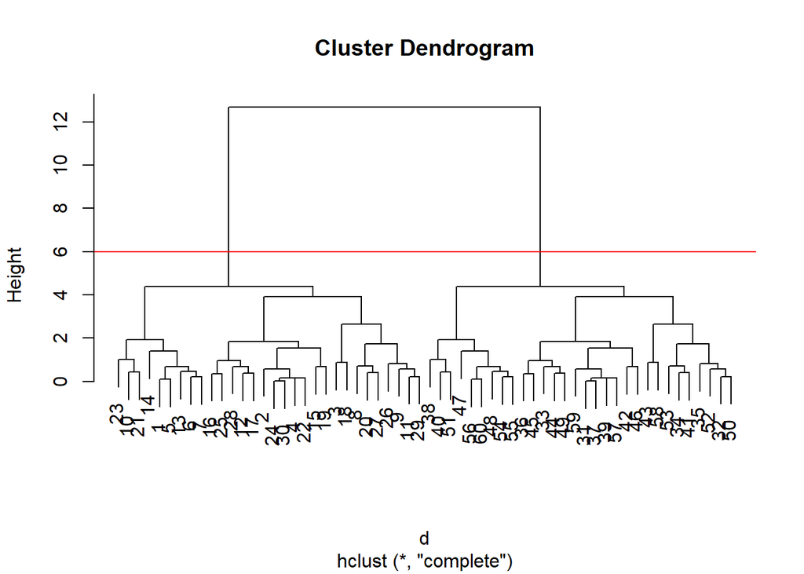

```r
plot(hc)
abline(h=6, col="red")
```

## # Cut into k grps can chang k

```r
cutree(hc, k=2)
```

```
##  [1] 1 1 1 1 1 1 1 1 1 1 1 1 1 1 1 1 1 1 1 1 1 1 1 1 1 1 1 1 1 1 2 2 2 2 2
## [36] 2 2 2 2 2 2 2 2 2 2 2 2 2 2 2 2 2 2 2 2 2 2 2 2 2
```

## Step 1. Generate some example data for clustering

```r
x <- rbind(
 matrix(rnorm(100, mean=0, sd = 0.3), ncol = 2), # c1
 matrix(rnorm(100, mean = 1, sd = 0.3), ncol = 2), # c2
 matrix(c(rnorm(50, mean = 1, sd = 0.3), # c3
 rnorm(50, mean = 0, sd = 0.3)), ncol = 2))
colnames(x) <- c("x", "y")
```

## Step 2. Plot the data without clustering

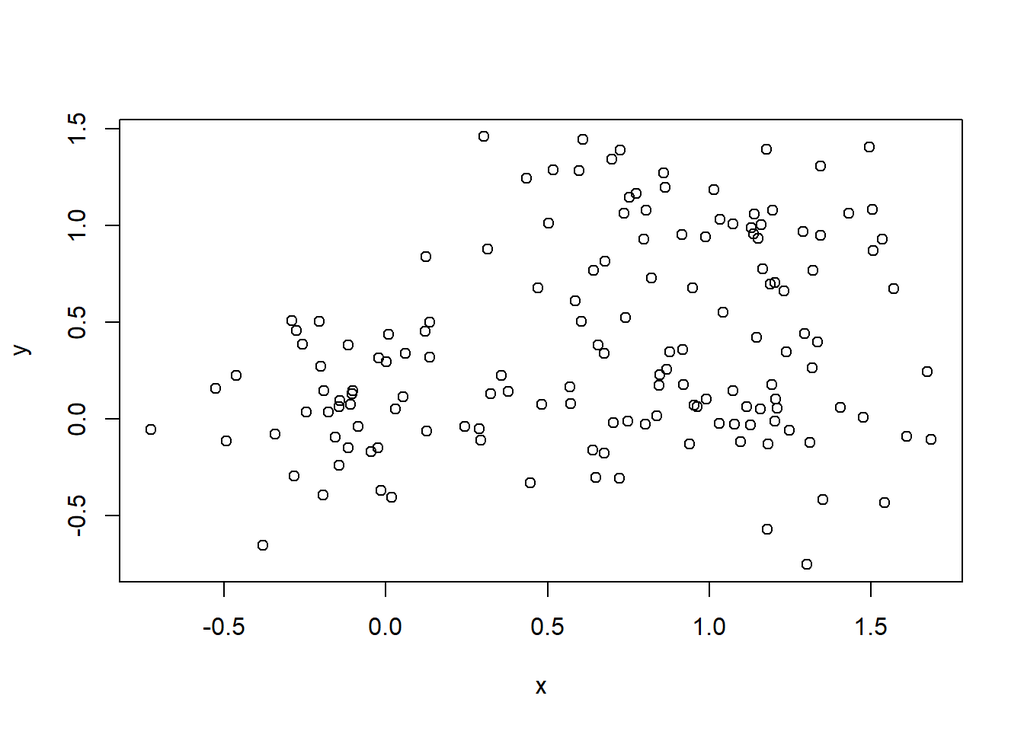

```r
plot(x)
```

# Step 3. Generate colors for known clusters # (just so we can compare to hclust results)

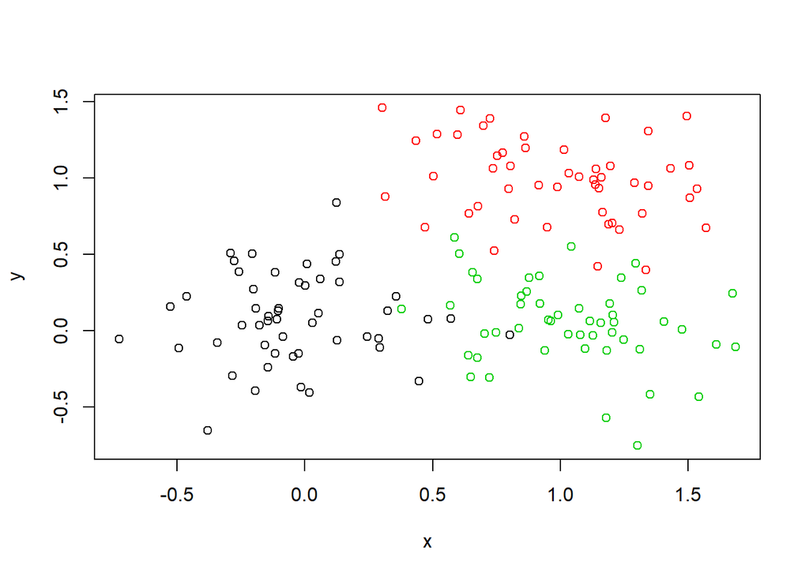

```r
col <- as.factor( rep(c("c1","c2","c3"), each=50) )
plot(x, col=col)
```

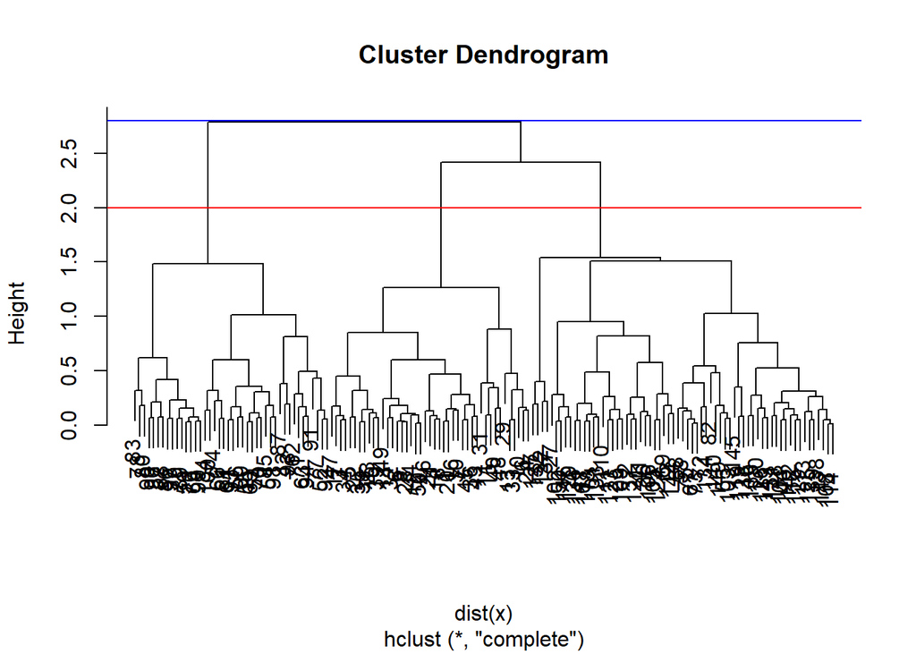

```r
hc<- hclust(dist(x))
plot(hc)
abline(h=2, col="red")
abline(h=2.8, col="blue")
```

```r
gp2 <- cutree(hc, k=4)
gp3<-cutree(hc, k=5)
```

```r
gp2
```

```
##   [1] 1 2 1 1 1 1 1 1 1 1 1 1 1 1 1 1 1 1 1 1 1 1 1 1 2 2 2 1 1 1 1 1 1 1 1
##  [36] 1 2 1 1 1 2 3 1 1 1 1 1 1 1 1 3 3 2 3 3 3 3 2 3 3 3 3 3 3 3 3 2 3 2 3
##  [71] 3 2 2 3 2 3 3 3 3 3 3 2 3 3 3 3 3 2 3 3 3 3 3 3 3 3 3 3 3 3 2 2 2 2 2
## [106] 2 2 2 2 2 2 2 2 2 2 2 2 2 2 2 2 4 2 2 2 2 4 2 2 2 2 4 2 2 2 2 4 2 2 2
## [141] 2 2 2 2 2 2 2 2 2 2
```

```r
gp3
```

```
##   [1] 1 2 1 1 1 1 1 1 1 1 1 1 1 1 1 1 1 1 1 1 1 1 1 1 2 2 2 1 1 1 1 1 1 1 1
##  [36] 1 2 1 1 1 2 3 1 1 1 1 1 1 1 1 3 3 4 3 3 3 3 4 3 3 3 3 3 3 3 3 4 3 2 3
##  [71] 3 4 4 3 4 3 3 3 3 3 3 4 3 3 3 3 3 4 3 3 3 3 3 3 3 3 3 3 3 3 2 2 4 4 2
## [106] 2 2 4 2 2 2 2 4 4 4 2 4 2 4 2 2 5 2 2 4 4 5 4 4 4 4 5 2 4 4 2 5 4 4 4
## [141] 2 4 4 2 4 4 4 4 4 2
```

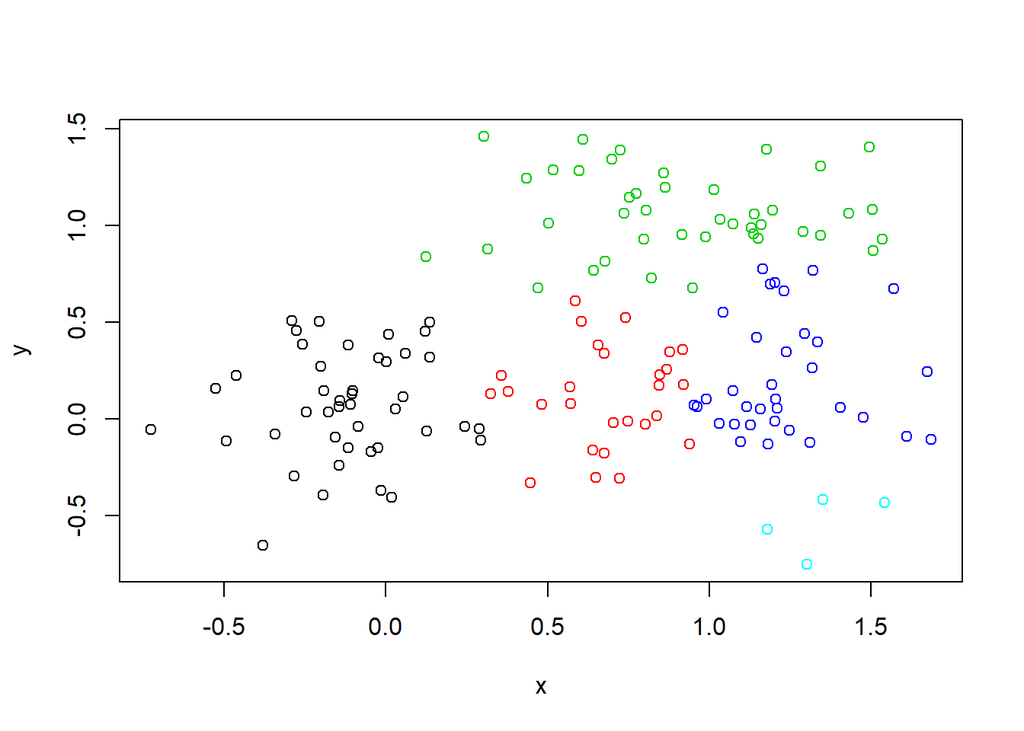

```r
plot(x, col=gp3)
```

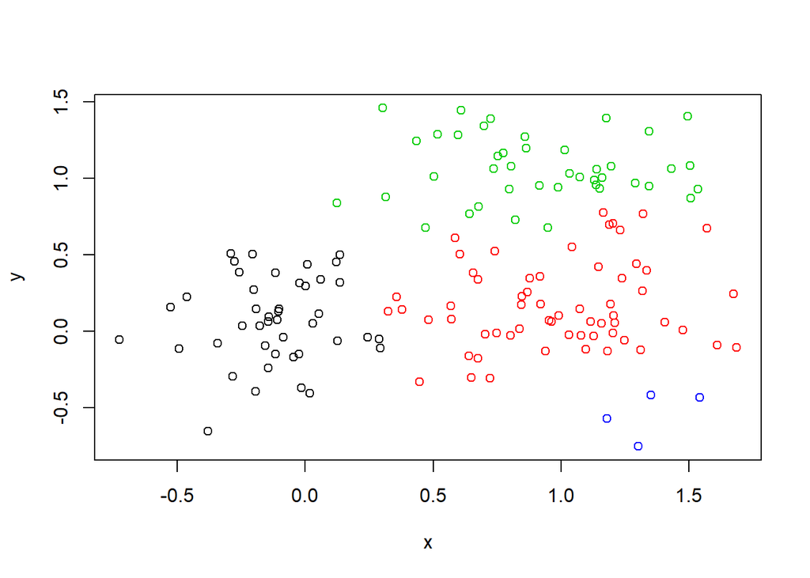

```r
plot(x, col=gp2)
```

##PCA analysis **prcomp()**

```r
mydata <- read.csv("https://tinyurl.com/expression-CSV",
 row.names=1)
```

## tells you how many rows #100 genes

```r
nrow(mydata)
```

```
## [1] 100
```

# how many experiment in colums

```r
ncol(mydata)
```

```
## [1] 10
```

## colum name

```r
colnames(mydata)
```

```
##  [1] "wt1" "wt2" "wt3" "wt4" "wt5" "ko1" "ko2" "ko3" "ko4" "ko5"
```

```r
head(t (mydata))
```

[output not shown]

[output cut: 15 more lines]

[output not shown]

```r
prcomp(t(mydata), scale=TRUE)
```

[output not shown]

[output cut: 253 more lines]

[output not shown]

#name pca

```r
pca <- prcomp(t(mydata), scale=TRUE)
```

# pca plot

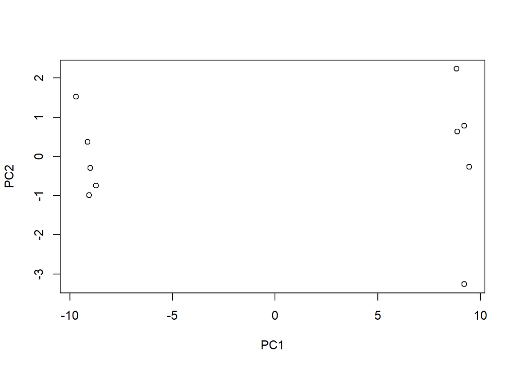

```r
plot(pca$x[,1], pca$x[,2], xlab="PC1", ylab="PC2")
```

## variance capture per PC % in OC

```r
pca.var <- pca$sdev^2
pca.var.per <- round(pca.var/sum(pca.var)*100, 1)

head(pca.var.per)
```

```
## [1] 92.6  2.3  1.1  1.1  0.8  0.7
```

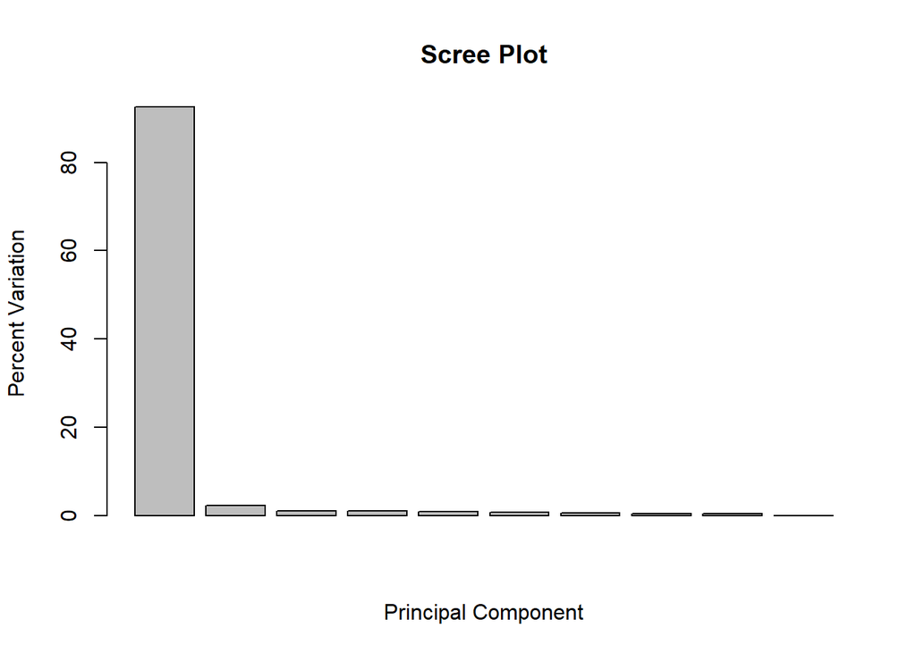

```r
barplot(pca.var.per, main="Scree Plot",
 xlab="Principal Component", ylab="Percent Variation")
```

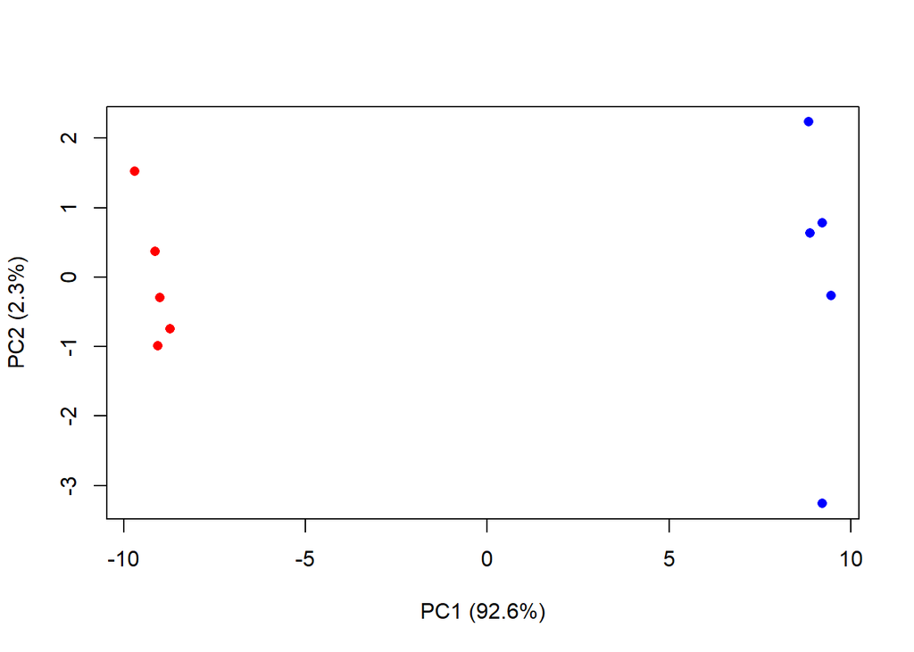

```r
colvec <- colnames(mydata)
colvec[grep("wt", colvec)] <- "red"
colvec[grep("ko", colvec)] <- "blue"

plot(pca$x[,1], pca$x[,2], col=colvec, pch=16,
 xlab=paste0("PC1 (", pca.var.per[1], "%)"),
 ylab=paste0("PC2 (", pca.var.per[2], "%)"))
```